# Credit Scoring

```r
install.packages("tidyverse")
install.packages(c("data.table", "fastDummies", "lightgbm", "reticulate", "keras"))
install.packages("ggmosaic")
install.packages("lightgbm")
```

```r
library(conflicted)
conflict_prefer("filter", "dplyr")
```

```
[conflicted] Removing existing preference.[conflicted] Will prefer dplyr::filter over any other package.
```

```r
conflict_prefer("lag", "dplyr")
```

```
[conflicted] Removing existing preference.[conflicted] Will prefer dplyr::lag over any other package.
```

```r
library(tidyverse)
library(data.table)         # To import csv sheets rapidly
library(dplyr)              #for data manipulation
library(fastDummies)        # For dummies
library(ggplot2)            # For the plots
library(gridExtra)          #to arrange 2 graphs in one row
library(lightgbm)           #for the model Light GBM
```

```r
load("bankruptcy.RData")
```

```r
## Data description
head(bankruptcy)
```

| Bankrupt? | ROA(C) before interest and depreciation before interest | ROA(A) before interest and % after tax | ROA(B) before interest and depreciation after tax | Operating Gross Margin | Realized Sales Gross Margin | Operating Profit Rate | Pre-tax net Interest Rate | After-tax net Interest Rate | Non-industry income and expenditure/revenue | Continuous interest rate (after tax) | Operating Expense Rate | Research and development expense rate | Cash flow rate | Interest-bearing debt interest rate | Tax rate (A) | Net Value Per Share (B) | Net Value Per Share (A) | Net Value Per Share (C) | Persistent EPS in the Last Four Seasons | Cash Flow Per Share | Revenue Per Share (Yuan ¥) | Operating Profit Per Share (Yuan ¥) | Per Share Net profit before tax (Yuan ¥) | Realized Sales Gross Profit Growth Rate | Operating Profit Growth Rate | After-tax Net Profit Growth Rate | Regular Net Profit Growth Rate | Continuous Net Profit Growth Rate | Total Asset Growth Rate | … |
| --- | --- | --- | --- | --- | --- | --- | --- | --- | --- | --- | --- | --- | --- | --- | --- | --- | --- | --- | --- | --- | --- | --- | --- | --- | --- | --- | --- | --- | --- | --- |
| 1 | 0.3705943 | 0.4243894 | 0.4057498 | 0.6014572 | 0.6014572 | 0.9989692 | 0.7968871 | 0.8088094 | 0.3026464 | 0.7809849 | 1.256969e-04 | 0 | 0.4581431 | 0.0007250725 | 0 | 0.1479499 | 0.1479499 | 0.1479499 | 0.1691406 | 0.3116644 | 0.017559780 | 0.09592053 | 0.1387362 | 0.02210228 | 0.8481950 | 0.6889795 | 0.6889795 | 0.2175354 | 4.98e+09 | … |
| 1 | 0.4642909 | 0.5382141 | 0.5167300 | 0.6102351 | 0.6102351 | 0.9989460 | 0.7973802 | 0.8093007 | 0.3035564 | 0.7815060 | 2.897851e-04 | 0 | 0.4618673 | 0.0006470647 | 0 | 0.1822511 | 0.1822511 | 0.1822511 | 0.2089439 | 0.3181368 | 0.021144335 | 0.09372201 | 0.1699179 | 0.02208017 | 0.8480879 | 0.6896929 | 0.6897017 | 0.2176196 | 6.11e+09 | … |
| 1 | 0.4260713 | 0.4990188 | 0.4722951 | 0.6014500 | 0.6013635 | 0.9988574 | 0.7964034 | 0.8083875 | 0.3020352 | 0.7802839 | 2.361297e-04 | 25500000 | 0.4585206 | 0.0007900790 | 0 | 0.1779107 | 0.1779107 | 0.1937129 | 0.1805805 | 0.3071019 | 0.005944008 | 0.09233776 | 0.1428033 | 0.02276010 | 0.8480940 | 0.6894627 | 0.6894697 | 0.2176013 | 7.28e+09 | … |
| 1 | 0.3998440 | 0.4512647 | 0.4577333 | 0.5835411 | 0.5835411 | 0.9986997 | 0.7969670 | 0.8089656 | 0.3033495 | 0.7812410 | 1.078888e-04 | 0 | 0.4657054 | 0.0004490449 | 0 | 0.1541865 | 0.1541865 | 0.1541865 | 0.1937222 | 0.3216736 | 0.014368468 | 0.07776240 | 0.1486028 | 0.02204607 | 0.8480055 | 0.6891095 | 0.6891095 | 0.2175682 | 4.88e+09 | … |
| 1 | 0.4650222 | 0.5384322 | 0.5222978 | 0.5987835 | 0.5987835 | 0.9989731 | 0.7973661 | 0.8093037 | 0.3034750 | 0.7815500 | 7.890000e+09 | 0 | 0.4627463 | 0.0006860686 | 0 | 0.1675024 | 0.1675024 | 0.1675024 | 0.2125366 | 0.3191625 | 0.029689792 | 0.09689765 | 0.1684115 | 0.02209591 | 0.8482582 | 0.6896969 | 0.6896969 | 0.2176256 | 5.51e+09 | … |
| 1 | 0.3886803 | 0.4151766 | 0.4191338 | 0.5901714 | 0.5902507 | 0.9987581 | 0.7969032 | 0.8087706 | 0.3031158 | 0.7810691 | 1.571500e-04 | 0 | 0.4658615 | 0.0007160716 | 0 | 0.1555771 | 0.1555771 | 0.1555771 | 0.1744351 | 0.3253873 | 0.018104270 | 0.07808810 | 0.1388115 | 0.02156494 | 0.8479828 | 0.6891051 | 0.6891775 | 0.2175664 | 6.08e+08 | … |

```r
tail(bankruptcy)
```

| Bankrupt? | ROA(C) before interest and depreciation before interest | ROA(A) before interest and % after tax | ROA(B) before interest and depreciation after tax | Operating Gross Margin | Realized Sales Gross Margin | Operating Profit Rate | Pre-tax net Interest Rate | After-tax net Interest Rate | Non-industry income and expenditure/revenue | Continuous interest rate (after tax) | Operating Expense Rate | Research and development expense rate | Cash flow rate | Interest-bearing debt interest rate | Tax rate (A) | Net Value Per Share (B) | Net Value Per Share (A) | Net Value Per Share (C) | Persistent EPS in the Last Four Seasons | Cash Flow Per Share | Revenue Per Share (Yuan ¥) | Operating Profit Per Share (Yuan ¥) | Per Share Net profit before tax (Yuan ¥) | Realized Sales Gross Profit Growth Rate | Operating Profit Growth Rate | After-tax Net Profit Growth Rate | Regular Net Profit Growth Rate | Continuous Net Profit Growth Rate | Total Asset Growth Rate | … |
| --- | --- | --- | --- | --- | --- | --- | --- | --- | --- | --- | --- | --- | --- | --- | --- | --- | --- | --- | --- | --- | --- | --- | --- | --- | --- | --- | --- | --- | --- | --- |
| 0 | 0.4775996 | 0.5311273 | 0.5260988 | 0.5958287 | 0.5958575 | 0.9989048 | 0.7973755 | 0.8092940 | 0.3036343 | 0.7815534 | 1.002568e-04 | 7.030000e+09 | 0.4639877 | 3.560356e-04 | 0.0000000 | 0.1806498 | 0.1806498 | 0.1806498 | 0.2132930 | 0.3219566 | 0.0242600239 | 0.08891784 | 0.1695413 | 0.02236178 | 0.8481275 | 0.6896853 | 0.6896853 | 0.2176266 | 5.98e+09 | … |
| 0 | 0.4936869 | 0.5394679 | 0.5432304 | 0.6044552 | 0.6044624 | 0.9989921 | 0.7974090 | 0.8093311 | 0.3035103 | 0.7815878 | 1.510213e-04 | 4.500000e+09 | 0.4637343 | 1.790179e-04 | 0.1133718 | 0.1750453 | 0.1750453 | 0.1750453 | 0.2166021 | 0.3209663 | 0.0207662175 | 0.09820047 | 0.1721021 | 0.02237376 | 0.8482045 | 0.6897781 | 0.6897781 | 0.2176353 | 7.07e+09 | … |
| 0 | 0.4751621 | 0.5382686 | 0.5241715 | 0.5983078 | 0.5983078 | 0.9989922 | 0.7974144 | 0.8093273 | 0.3035197 | 0.7815861 | 5.220000e+09 | 1.440000e+09 | 0.4619780 | 2.370237e-04 | 0.3715963 | 0.1813240 | 0.1813240 | 0.1813240 | 0.2166966 | 0.3182783 | 0.0230500476 | 0.09860761 | 0.1727800 | 0.02215937 | 0.8482448 | 0.6897340 | 0.6897340 | 0.2176314 | 5.22e+09 | … |
| 0 | 0.4727246 | 0.5337440 | 0.5206381 | 0.6104441 | 0.6102135 | 0.9989845 | 0.7974009 | 0.8093169 | 0.3035122 | 0.7815464 | 2.509312e-04 | 1.039086e-04 | 0.4721891 | 0.000000e+00 | 0.4908392 | 0.2695209 | 0.2695209 | 0.2695209 | 0.2109294 | 0.3248568 | 0.0442548815 | 0.10007328 | 0.1732319 | 0.02206835 | 0.8479776 | 0.6892021 | 0.6892021 | 0.2175472 | 5.99e+09 | … |
| 0 | 0.5062643 | 0.5599106 | 0.5540446 | 0.6078496 | 0.6078496 | 0.9990738 | 0.7974999 | 0.8093994 | 0.3034982 | 0.7816633 | 1.236154e-04 | 2.510000e+09 | 0.4761229 | 2.110211e-04 | 0.1812937 | 0.2133918 | 0.2133918 | 0.2133918 | 0.2283256 | 0.3465728 | 0.0315350061 | 0.11179871 | 0.1855841 | 0.02234993 | 0.8540638 | 0.6961128 | 0.6961128 | 0.2180056 | 7.25e+09 | … |
| 0 | 0.4930532 | 0.5701047 | 0.5495476 | 0.6274089 | 0.6274089 | 0.9980803 | 0.8019867 | 0.8137996 | 0.3134153 | 0.7860790 | 1.431695e-03 | 0.000000e+00 | 0.4277212 | 5.900000e+08 | 0.0000000 | 0.2207661 | 0.2207661 | 0.2207661 | 0.2277583 | 0.3057933 | 0.0006654869 | 0.09250061 | 0.1821195 | 0.02531588 | 0.8480531 | 0.6895266 | 0.6895266 | 0.2176049 | 9.35e+09 | … |

```r
summary(bankruptcy)
```

```
   Bankrupt?       ROA(C) before interest and depreciation before interest ROA(A) before interest and % after tax
 Min.   :0.00000   Min.   :0.0000                                          Min.   :0.0000
 1st Qu.:0.00000   1st Qu.:0.4765                                          1st Qu.:0.5355
 Median :0.00000   Median :0.5027                                          Median :0.5598
 Mean   :0.03226   Mean   :0.5052                                          Mean   :0.5586
 3rd Qu.:0.00000   3rd Qu.:0.5356                                          3rd Qu.:0.5892
 Max.   :1.00000   Max.   :1.0000                                          Max.   :1.0000
 ROA(B) before interest and depreciation after tax Operating Gross Margin Realized Sales Gross Margin Operating Profit Rate
 Min.   :0.0000                                    Min.   :0.0000         Min.   :0.0000              Min.   :0.0000
 1st Qu.:0.5273                                    1st Qu.:0.6004         1st Qu.:0.6004              1st Qu.:0.9990
 Median :0.5523                                    Median :0.6060         Median :0.6060              Median :0.9990
 Mean   :0.5536                                    Mean   :0.6079         Mean   :0.6079              Mean   :0.9988
 3rd Qu.:0.5841                                    3rd Qu.:0.6139         3rd Qu.:0.6138              3rd Qu.:0.9991
 Max.   :1.0000                                    Max.   :1.0000         Max.   :1.0000              Max.   :1.0000
 Pre-tax net Interest Rate After-tax net Interest Rate Non-industry income and expenditure/revenue Continuous interest rate (after tax)
 Min.   :0.0000            Min.   :0.0000              Min.   :0.0000                              Min.   :0.0000
 1st Qu.:0.7974            1st Qu.:0.8093              1st Qu.:0.3035                              1st Qu.:0.7816
 Median :0.7975            Median :0.8094              Median :0.3035                              Median :0.7816
 Mean   :0.7972            Mean   :0.8091              Mean   :0.3036                              Mean   :0.7814
 3rd Qu.:0.7976            3rd Qu.:0.8095              3rd Qu.:0.3036                              3rd Qu.:0.7817
 Max.   :1.0000            Max.   :1.0000              Max.   :1.0000                              Max.   :1.0000
 Operating Expense Rate Research and development expense rate Cash flow rate   Interest-bearing debt interest rate  Tax rate (A)
 Min.   :0.000e+00      Min.   :0.00e+00                      Min.   :0.0000   Min.   :        0                   Min.   :0.00000
 1st Qu.:0.000e+00      1st Qu.:0.00e+00                      1st Qu.:0.4616   1st Qu.:        0                   1st Qu.:0.00000
 Median :0.000e+00      Median :5.09e+08                      Median :0.4651   Median :        0                   Median :0.07349
 Mean   :1.995e+09      Mean   :1.95e+09                      Mean   :0.4674   Mean   : 16448013                   Mean   :0.11500
 3rd Qu.:4.145e+09      3rd Qu.:3.45e+09                      3rd Qu.:0.4710   3rd Qu.:        0                   3rd Qu.:0.20584
 Max.   :9.990e+09      Max.   :9.98e+09                      Max.   :1.0000   Max.   :990000000                   Max.   :1.00000
 Net Value Per Share (B) Net Value Per Share (A) Net Value Per Share (C) Persistent EPS in the Last Four Seasons Cash Flow Per Share
 Min.   :0.0000          Min.   :0.0000          Min.   :0.0000          Min.   :0.0000                          Min.   :0.0000
 1st Qu.:0.1736          1st Qu.:0.1736          1st Qu.:0.1737          1st Qu.:0.2147                          1st Qu.:0.3177
 Median :0.1844          Median :0.1844          Median :0.1844          Median :0.2245                          Median :0.3225
 Mean   :0.1907          Mean   :0.1906          Mean   :0.1907          Mean   :0.2288                          Mean   :0.3235
 3rd Qu.:0.1996          3rd Qu.:0.1996          3rd Qu.:0.1996          3rd Qu.:0.2388                          3rd Qu.:0.3286
 Max.   :1.0000          Max.   :1.0000          Max.   :1.0000          Max.   :1.0000                          Max.   :1.0000
 Revenue Per Share (Yuan ¥) Operating Profit Per Share (Yuan ¥) Per Share Net profit before tax (Yuan ¥)
 Min.   :0.000e+00          Min.   :0.00000                     Min.   :0.0000
 1st Qu.:0.000e+00          1st Qu.:0.09608                     1st Qu.:0.1704
 Median :0.000e+00          Median :0.10423                     Median :0.1797
 Mean   :1.329e+06          Mean   :0.10909                     Mean   :0.1844
```

[output cut: 106 more lines]

```
 Max.   :1.000000      Max.   :1.0000             Max.   :9.820e+09         Max.   :1.0000     Max.   :1.0000
 Net Income to Stockholder's Equity Liability to Equity Degree of Financial Leverage (DFL)
 Min.   :0.0000                     Min.   :0.0000      Min.   :0.00000
 1st Qu.:0.8401                     1st Qu.:0.2769      1st Qu.:0.02679
 Median :0.8412                     Median :0.2788      Median :0.02681
 Mean   :0.8404                     Mean   :0.2804      Mean   :0.02754
 3rd Qu.:0.8424                     3rd Qu.:0.2814      3rd Qu.:0.02691
 Max.   :1.0000                     Max.   :1.0000      Max.   :1.00000
 Interest Coverage Ratio (Interest expense to EBIT) Net Income Flag Equity to Liability
 Min.   :0.0000                                     Min.   :1       Min.   :0.00000
 1st Qu.:0.5652                                     1st Qu.:1       1st Qu.:0.02448
 Median :0.5653                                     Median :1       Median :0.03380
 Mean   :0.5654                                     Mean   :1       Mean   :0.04758
 3rd Qu.:0.5657                                     3rd Qu.:1       3rd Qu.:0.05284
 Max.   :1.0000                                     Max.   :1       Max.   :1.00000
```

```r
glimpse(bankruptcy)
```

```
Rows: 6,819
Columns: 96
$ `Bankrupt?`                                               <dbl> 1, 1, 1, 1, 1, 1, 0, 0, 0, 0, 0, 0, 0, 0, 0, 0, 0, 0, 0, 0, 0, 0, 0,…
$ `ROA(C) before interest and depreciation before interest` <dbl> 0.3705943, 0.4642909, 0.4260713, 0.3998440, 0.4650222, 0.3886803, 0.…
$ `ROA(A) before interest and % after tax`                  <dbl> 0.4243894, 0.5382141, 0.4990188, 0.4512647, 0.5384322, 0.4151766, 0.…
$ `ROA(B) before interest and depreciation after tax`       <dbl> 0.4057498, 0.5167300, 0.4722951, 0.4577333, 0.5222978, 0.4191338, 0.…
$ `Operating Gross Margin`                                  <dbl> 0.6014572, 0.6102351, 0.6014500, 0.5835411, 0.5987835, 0.5901714, 0.…
$ `Realized Sales Gross Margin`                             <dbl> 0.6014572, 0.6102351, 0.6013635, 0.5835411, 0.5987835, 0.5902507, 0.…
$ `Operating Profit Rate`                                   <dbl> 0.9989692, 0.9989460, 0.9988574, 0.9986997, 0.9989731, 0.9987581, 0.…
$ `Pre-tax net Interest Rate`                               <dbl> 0.7968871, 0.7973802, 0.7964034, 0.7969670, 0.7973661, 0.7969032, 0.…
$ `After-tax net Interest Rate`                             <dbl> 0.8088094, 0.8093007, 0.8083875, 0.8089656, 0.8093037, 0.8087706, 0.…
$ `Non-industry income and expenditure/revenue`             <dbl> 0.3026464, 0.3035564, 0.3020352, 0.3033495, 0.3034750, 0.3031158, 0.…
$ `Continuous interest rate (after tax)`                    <dbl> 0.7809849, 0.7815060, 0.7802839, 0.7812410, 0.7815500, 0.7810691, 0.…
$ `Operating Expense Rate`                                  <dbl> 1.256969e-04, 2.897851e-04, 2.361297e-04, 1.078888e-04, 7.890000e+09…
$ `Research and development expense rate`                   <dbl> 0.00e+00, 0.00e+00, 2.55e+07, 0.00e+00, 0.00e+00, 0.00e+00, 7.30e+08…
```

[output cut: 83 more lines]

```r
## Checking missing values
colSums(is.na(bankruptcy)) ## result shows no nulls
```

```
                                              Bankrupt? ROA(C) before interest and depreciation before interest
                                                      0                                                       0
                 ROA(A) before interest and % after tax       ROA(B) before interest and depreciation after tax
                                                      0                                                       0
                                 Operating Gross Margin                             Realized Sales Gross Margin
                                                      0                                                       0
                                  Operating Profit Rate                               Pre-tax net Interest Rate
                                                      0                                                       0
                            After-tax net Interest Rate             Non-industry income and expenditure/revenue
                                                      0                                                       0
                   Continuous interest rate (after tax)                                  Operating Expense Rate
                                                      0                                                       0
                  Research and development expense rate                                          Cash flow rate
                                                      0                                                       0
                    Interest-bearing debt interest rate                                            Tax rate (A)
                                                      0                                                       0
                                Net Value Per Share (B)                                 Net Value Per Share (A)
                                                      0                                                       0
                                Net Value Per Share (C)                 Persistent EPS in the Last Four Seasons
                                                      0                                                       0
                                    Cash Flow Per Share                              Revenue Per Share (Yuan ¥)
                                                      0                                                       0
                    Operating Profit Per Share (Yuan ¥)                Per Share Net profit before tax (Yuan ¥)
                                                      0                                                       0
                Realized Sales Gross Profit Growth Rate                            Operating Profit Growth Rate
                                                      0                                                       0
                       After-tax Net Profit Growth Rate                          Regular Net Profit Growth Rate
                                                      0                                                       0
                      Continuous Net Profit Growth Rate                                 Total Asset Growth Rate
                                                      0                                                       0
                                  Net Value Growth Rate                    Total Asset Return Growth Rate Ratio
                                                      0                                                       0
                                    Cash Reinvestment %                                           Current Ratio
                                                      0                                                       0
                                            Quick Ratio                                  Interest Expense Ratio
                                                      0                                                       0
                             Total debt/Total net worth                                            Debt ratio %
                                                      0                                                       0
                                       Net worth/Assets                    Long-term fund suitability ratio (A)
                                                      0                                                       0
```

[output cut: 41 more lines]

```
                                                      0                                                       0
                                          CFO to Assets                                     Cash Flow to Equity
                                                      0                                                       0
                    Current Liability to Current Assets                                   Liability-Assets Flag
                                                      0                                                       0
                             Net Income to Total Assets                               Total assets to GNP price
                                                      0                                                       0
                                     No-credit Interval                                   Gross Profit to Sales
                                                      0                                                       0
                     Net Income to Stockholder's Equity                                     Liability to Equity
                                                      0                                                       0
                     Degree of Financial Leverage (DFL)      Interest Coverage Ratio (Interest expense to EBIT)
                                                      0                                                       0
                                        Net Income Flag                                     Equity to Liability
                                                      0                                                       0
```

```r
## Structure
str(bankruptcy[,1:15]) ## Provides data structure, datatype
```

```
tibble [6,819 × 15] (S3: tbl_df/tbl/data.frame)
 $ Bankrupt?                                              : num [1:6819] 1 1 1 1 1 1 0 0 0 0 ...
 $ ROA(C) before interest and depreciation before interest: num [1:6819] 0.371 0.464 0.426 0.4 0.465 ...
 $ ROA(A) before interest and % after tax                 : num [1:6819] 0.424 0.538 0.499 0.451 0.538 ...
 $ ROA(B) before interest and depreciation after tax      : num [1:6819] 0.406 0.517 0.472 0.458 0.522 ...
 $ Operating Gross Margin                                 : num [1:6819] 0.601 0.61 0.601 0.584 0.599 ...
 $ Realized Sales Gross Margin                            : num [1:6819] 0.601 0.61 0.601 0.584 0.599 ...
 $ Operating Profit Rate                                  : num [1:6819] 0.999 0.999 0.999 0.999 0.999 ...
 $ Pre-tax net Interest Rate                              : num [1:6819] 0.797 0.797 0.796 0.797 0.797 ...
 $ After-tax net Interest Rate                            : num [1:6819] 0.809 0.809 0.808 0.809 0.809 ...
 $ Non-industry income and expenditure/revenue            : num [1:6819] 0.303 0.304 0.302 0.303 0.303 ...
 $ Continuous interest rate (after tax)                   : num [1:6819] 0.781 0.782 0.78 0.781 0.782 ...
 $ Operating Expense Rate                                 : num [1:6819] 1.26e-04 2.90e-04 2.36e-04 1.08e-04 7.89e+09 ...
 $ Research and development expense rate                  : num [1:6819] 0.00 0.00 2.55e+07 0.00 0.00 0.00 7.30e+08 5.09e+07 0.00 0.00 ...
 $ Cash flow rate                                         : num [1:6819] 0.458 0.462 0.459 0.466 0.463 ...
 $ Interest-bearing debt interest rate                    : num [1:6819] 0.000725 0.000647 0.00079 0.000449 0.000686 ...
```

```r
## all are numerical values
```

```r
## Statistics
library(psych)
describe(bankruptcy)
```

|  | vars | n | mean | sd | median | trimmed | mad | min | max | range | skew | kurtosis | se |
| --- | --- | --- | --- | --- | --- | --- | --- | --- | --- | --- | --- | --- | --- |
| Bankrupt? | 1 | 6819 | 3.000000e-02 | 1.800000e-01 | 0.00e+00 | 0.000000e+00 | 0.000000e+00 | 0 | 1.00e+00 | 1.00e+00 | 5.29 | 26.02 | 0.0 |
| ROA(C) before interest and depreciation before interest | 2 | 6819 | 5.100000e-01 | 6.000000e-02 | 5.00e-01 | 5.100000e-01 | 4.000000e-02 | 0 | 1.00e+00 | 1.00e+00 | -0.32 | 6.38 | 0.0 |
| ROA(A) before interest and % after tax | 3 | 6819 | 5.600000e-01 | 7.000000e-02 | 5.60e-01 | 5.600000e-01 | 4.000000e-02 | 0 | 1.00e+00 | 1.00e+00 | -1.03 | 9.03 | 0.0 |
| ROA(B) before interest and depreciation after tax | 4 | 6819 | 5.500000e-01 | 6.000000e-02 | 5.50e-01 | 5.500000e-01 | 4.000000e-02 | 0 | 1.00e+00 | 1.00e+00 | -0.76 | 7.92 | 0.0 |
| Operating Gross Margin | 5 | 6819 | 6.100000e-01 | 2.000000e-02 | 6.10e-01 | 6.100000e-01 | 1.000000e-02 | 0 | 1.00e+00 | 1.00e+00 | -8.04 | 365.16 | 0.0 |
| Realized Sales Gross Margin | 6 | 6819 | 6.100000e-01 | 2.000000e-02 | 6.10e-01 | 6.100000e-01 | 1.000000e-02 | 0 | 1.00e+00 | 1.00e+00 | -8.06 | 366.66 | 0.0 |
| Operating Profit Rate | 7 | 6819 | 1.000000e+00 | 1.000000e-02 | 1.00e+00 | 1.000000e+00 | 0.000000e+00 | 0 | 1.00e+00 | 1.00e+00 | -70.21 | 5204.74 | 0.0 |
| Pre-tax net Interest Rate | 8 | 6819 | 8.000000e-01 | 1.000000e-02 | 8.00e-01 | 8.000000e-01 | 0.000000e+00 | 0 | 1.00e+00 | 1.00e+00 | -52.46 | 3049.90 | 0.0 |
| After-tax net Interest Rate | 9 | 6819 | 8.100000e-01 | 1.000000e-02 | 8.10e-01 | 8.100000e-01 | 0.000000e+00 | 0 | 1.00e+00 | 1.00e+00 | -52.97 | 3026.01 | 0.0 |
| Non-industry income and expenditure/revenue | 10 | 6819 | 3.000000e-01 | 1.000000e-02 | 3.00e-01 | 3.000000e-01 | 0.000000e+00 | 0 | 1.00e+00 | 1.00e+00 | 39.62 | 2646.71 | 0.0 |

[output cut: 86 more lines]

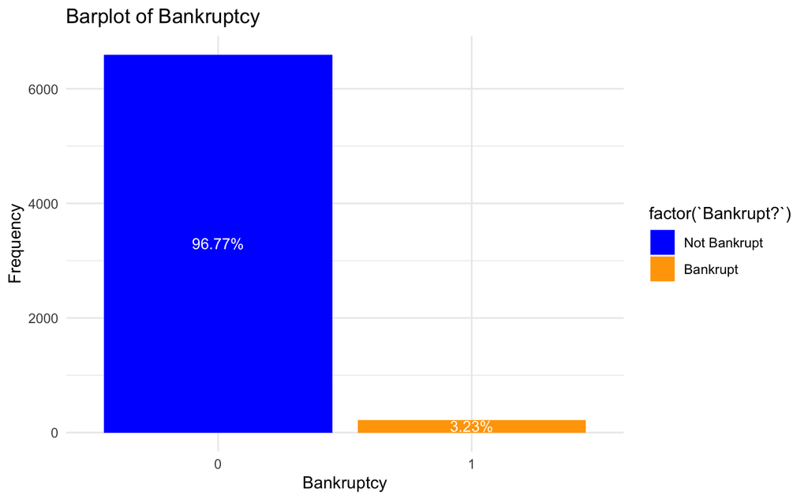

```r
## Histogram
bankruptcy_counts <- bankruptcy %>%
  group_by(`Bankrupt?`) %>%
  summarise(Count = n()) %>%
  mutate(Percent = Count / sum(Count) * 100)

# Now create the plot
ggplot(bankruptcy_counts, aes(x = factor(`Bankrupt?`), y = Count, fill = factor(`Bankrupt?`))) +
  geom_bar(stat = "identity") +
  geom_text(aes(label = sprintf("%.2f%%", Percent)),
            position = position_stack(vjust = 0.5),
            color = "white", size = 3.5) +
  labs(title = "Barplot of Bankruptcy", x = "Bankruptcy", y = "Frequency") +
  scale_fill_manual(values = c("blue", "orange"),
                    labels = c("Not Bankrupt", "Bankrupt")) +
  theme_minimal()
```

```r
# imbalance dataset, only 3.23% of bankrupt data is recorded
```

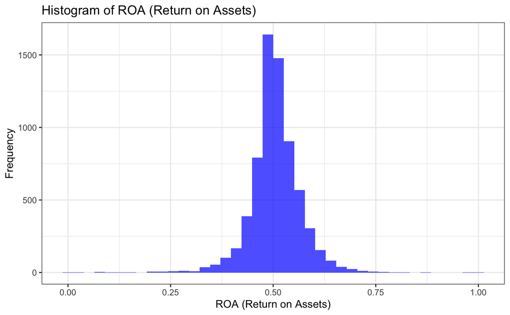

```r
options(repr.plot.width = 6, repr.plot.height = 3) # Resize plot option

bankruptcy |>
  ggplot(aes(x = `ROA(C) before interest and depreciation before interest`)) +
  geom_histogram(alpha = 0.7, bins = 40, fill = "blue") +
  theme_bw() +
  scale_x_continuous(labels = scales::comma) +
  labs(title = "Histogram of ROA (Return on Assets)",
       x = "ROA (Return on Assets)",
       y = "Frequency")
```

The histogram also evidences elongated tails on both extremities of the ROA spectrum, alluding to the existence of statistical outliers. Such outliers may correspond to enterprises with atypically elevated profitability ratios or those possibly experiencing substantial fiscal distress. The presence of such extreme values may necessitate further investigation to ascertain their influence on the overall analysis and potential implications for financial robustness and risk of insolvency.

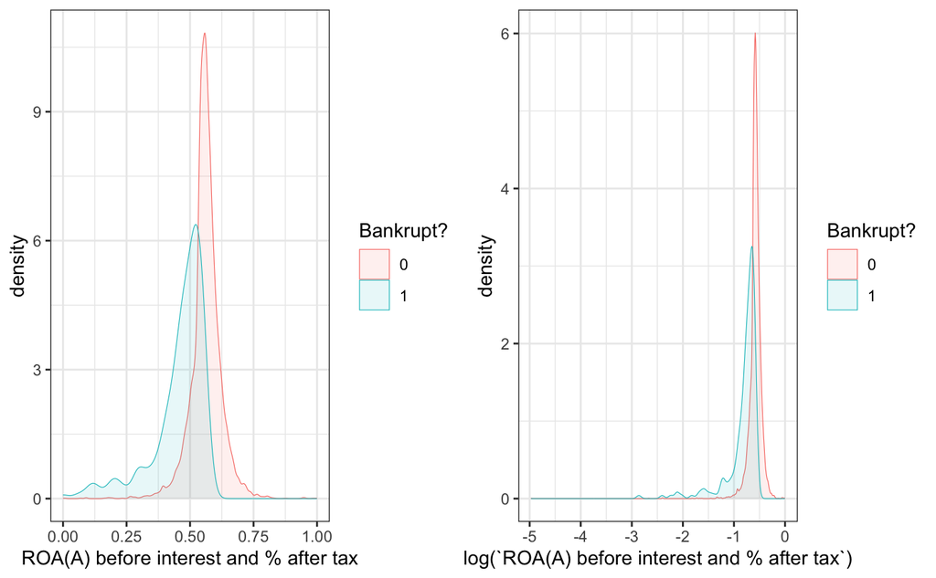

```r
library(gridExtra)

options(repr.plot.width=9, repr.plot.height=3) # Resize plot option

g1 <- ggplot(data = bankruptcy, aes(x=`ROA(A) before interest and % after tax`, fill=factor(`Bankrupt?`), colour=factor(`Bankrupt?`))) +
  geom_density(alpha=0.1, linewidth=0.2) +
  theme_bw() + labs(fill='Bankrupt?') + labs(colour='Bankrupt?')

g2 <- ggplot(data = bankruptcy, aes(x=log(`ROA(A) before interest and % after tax`), fill=factor(`Bankrupt?`), colour=factor(`Bankrupt?`))) +
  geom_density(alpha=0.1, linewidth=0.2) +
  theme_bw() + labs(fill='Bankrupt?') + labs(colour='Bankrupt?')

grid.arrange(g1, g2, ncol=2)
```

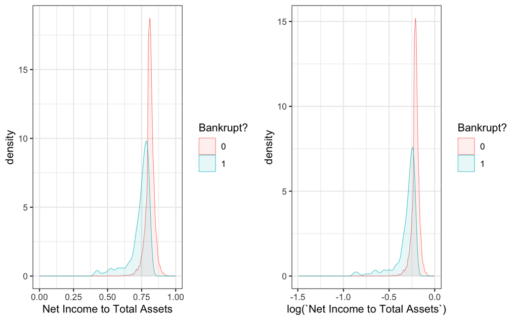

```r
options(repr.plot.width=9, repr.plot.height=3) # Resize plot option

g1 <- ggplot(data = bankruptcy, aes(x=`Net Income to Total Assets`, fill=factor(`Bankrupt?`), colour=factor(`Bankrupt?`))) +
  geom_density(alpha=0.1, linewidth=0.2) +
  theme_bw() + labs(fill='Bankrupt?') + labs(colour='Bankrupt?')

g2 <- ggplot(data = bankruptcy, aes(x=log(`Net Income to Total Assets`), fill=factor(`Bankrupt?`), colour=factor(`Bankrupt?`))) +
  geom_density(alpha=0.1, linewidth=0.2) +
  theme_bw() + labs(fill='Bankrupt?') + labs(colour='Bankrupt?')

grid.arrange(g1, g2, ncol=2)
```

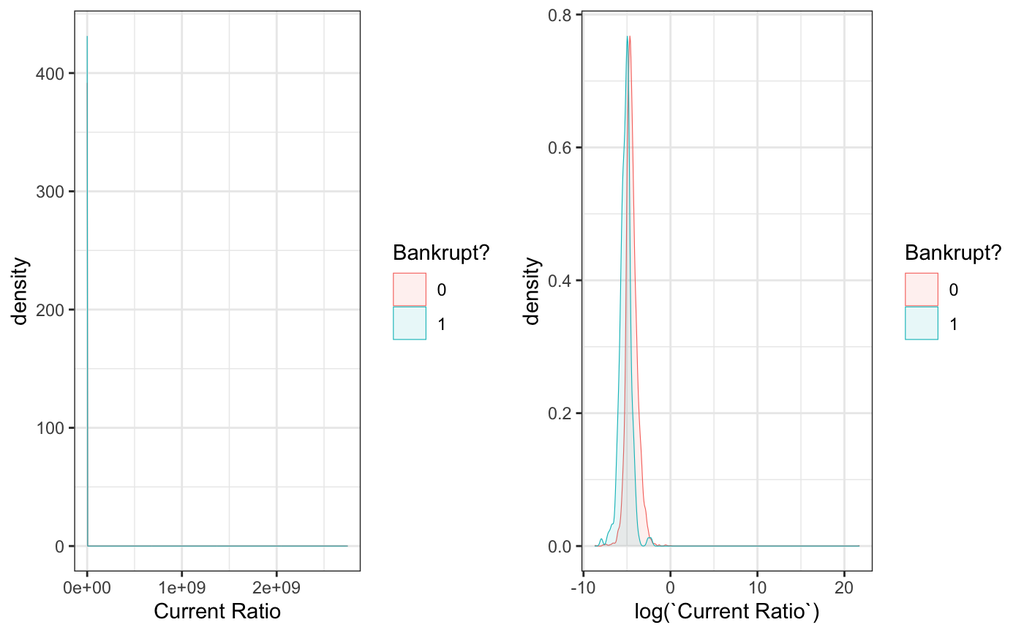

```r
options(repr.plot.width=9, repr.plot.height=3) # Resize plot option

g1 <- ggplot(data = bankruptcy, aes(x=`Current Ratio`, fill=factor(`Bankrupt?`), colour=factor(`Bankrupt?`))) +
  geom_density(alpha=0.1, linewidth=0.2) +
  theme_bw() + labs(fill='Bankrupt?') + labs(colour='Bankrupt?')

g2 <- ggplot(data = bankruptcy, aes(x=log(`Current Ratio`), fill=factor(`Bankrupt?`), colour=factor(`Bankrupt?`))) +
  geom_density(alpha=0.1, linewidth=0.2) +
  theme_bw() + labs(fill='Bankrupt?') + labs(colour='Bankrupt?')

grid.arrange(g1, g2, ncol=2)
```

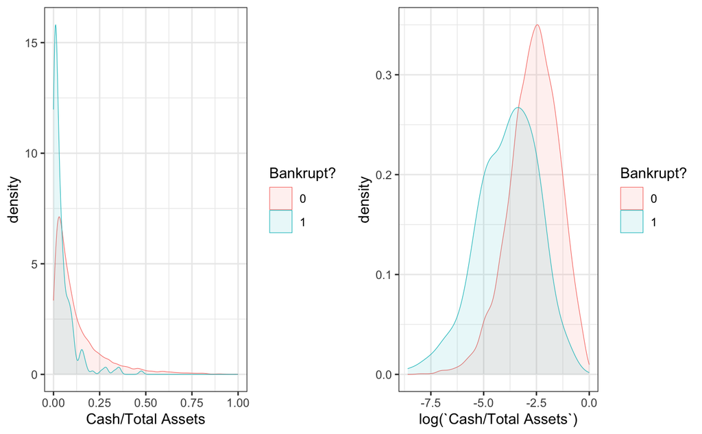

```r
options(repr.plot.width=9, repr.plot.height=3) # Resize plot option

g1 <- ggplot(data = bankruptcy, aes(x=`Cash/Total Assets`, fill=factor(`Bankrupt?`), colour=factor(`Bankrupt?`))) +
  geom_density(alpha=0.1, linewidth=0.2) +
  theme_bw() + labs(fill='Bankrupt?') + labs(colour='Bankrupt?')

g2 <- ggplot(data = bankruptcy, aes(x=log(`Cash/Total Assets`), fill=factor(`Bankrupt?`), colour=factor(`Bankrupt?`))) +
  geom_density(alpha=0.1, linewidth=0.2) +
  theme_bw() + labs(fill='Bankrupt?') + labs(colour='Bankrupt?')

grid.arrange(g1, g2, ncol=2)
```

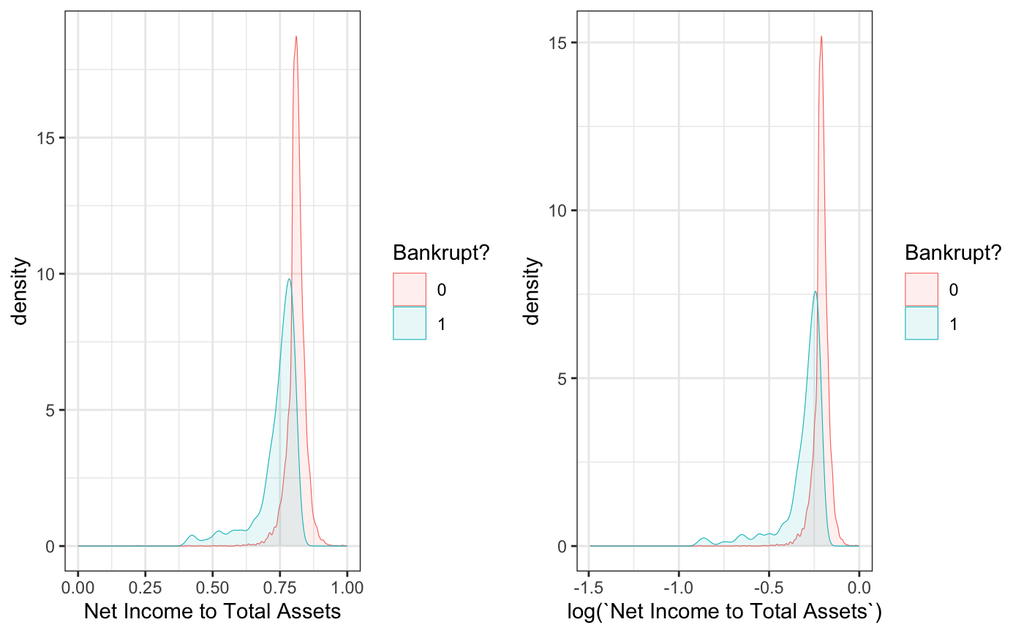

```r
options(repr.plot.width=9, repr.plot.height=3) # Resize plot option

g1 <- ggplot(data = bankruptcy, aes(x=`Net Income to Total Assets`, fill=factor(`Bankrupt?`), colour=factor(`Bankrupt?`))) +
  geom_density(alpha=0.1, linewidth=0.2) +
  theme_bw() + labs(fill='Bankrupt?') + labs(colour='Bankrupt?')

g2 <- ggplot(data = bankruptcy, aes(x=log(`Net Income to Total Assets`), fill=factor(`Bankrupt?`), colour=factor(`Bankrupt?`))) +
  geom_density(alpha=0.1, linewidth=0.2) +
  theme_bw() + labs(fill='Bankrupt?') + labs(colour='Bankrupt?')

grid.arrange(g1, g2, ncol=2)
```

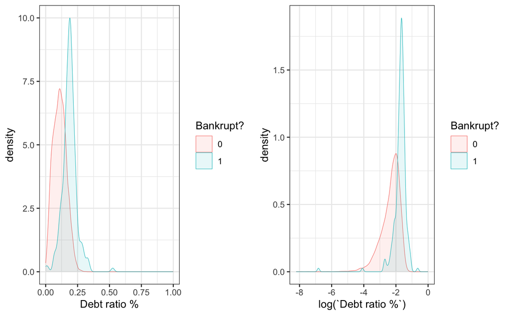

```r
options(repr.plot.width=9, repr.plot.height=3) # Resize plot option

g1 <- ggplot(data = bankruptcy, aes(x=`Debt ratio %`, fill=factor(`Bankrupt?`), colour=factor(`Bankrupt?`))) +
  geom_density(alpha=0.1, linewidth=0.2) +
  theme_bw() + labs(fill='Bankrupt?') + labs(colour='Bankrupt?')

g2 <- ggplot(data = bankruptcy, aes(x=log(`Debt ratio %`), fill=factor(`Bankrupt?`), colour=factor(`Bankrupt?`))) +
  geom_density(alpha=0.1, linewidth=0.2) +
  theme_bw() + labs(fill='Bankrupt?') + labs(colour='Bankrupt?')

grid.arrange(g1, g2, ncol=2)
```

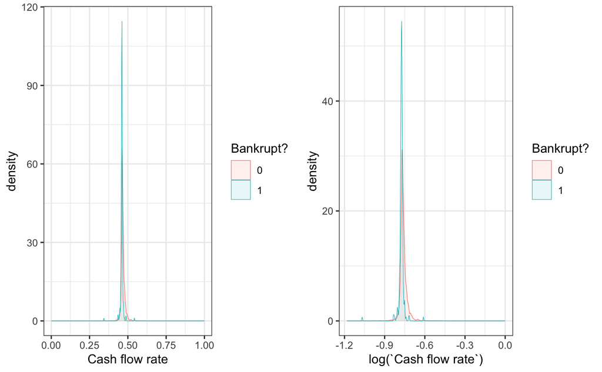

```r
options(repr.plot.width=9, repr.plot.height=3) # Resize plot option

g1 <- ggplot(data = bankruptcy, aes(x=`Cash flow rate`, fill=factor(`Bankrupt?`), colour=factor(`Bankrupt?`))) +
  geom_density(alpha=0.1, linewidth=0.2) +
  theme_bw() + labs(fill='Bankrupt?') + labs(colour='Bankrupt?')

g2 <- ggplot(data = bankruptcy, aes(x=log(`Cash flow rate`), fill=factor(`Bankrupt?`), colour=factor(`Bankrupt?`))) +
  geom_density(alpha=0.1, linewidth=0.2) +
  theme_bw() + labs(fill='Bankrupt?') + labs(colour='Bankrupt?')

grid.arrange(g1, g2, ncol=2)
```

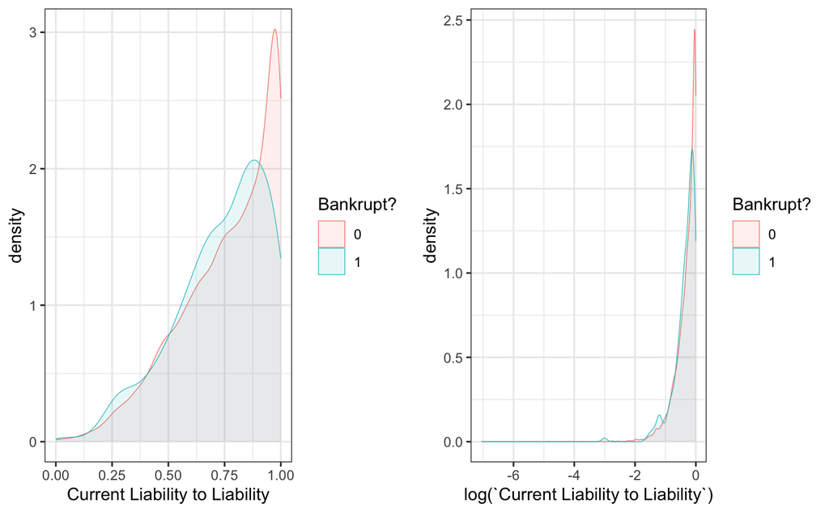

```r
options(repr.plot.width=9, repr.plot.height=3) # Resize plot option
g1 <- ggplot(data = bankruptcy, aes(x=`Current Liability to Liability`, fill=factor(`Bankrupt?`), colour=factor(`Bankrupt?`))) +
  geom_density(alpha=0.1, linewidth=0.2) +
  theme_bw() + labs(fill='Bankrupt?') + labs(colour='Bankrupt?')

g2 <- ggplot(data = bankruptcy, aes(x=log(`Current Liability to Liability`), fill=factor(`Bankrupt?`), colour=factor(`Bankrupt?`))) +
  geom_density(alpha=0.1, linewidth=0.2) +
  theme_bw() + labs(fill='Bankrupt?') + labs(colour='Bankrupt?')

grid.arrange(g1, g2, ncol=2)
```

In these visual data representations, firms not undergoing bankruptcy exhibit financial indicators with distributions skewed towards more favorable economic conditions, reflected by elevated peaks at higher quantiles of profitability, solvency, and liquidity ratios. Conversely, entities within the bankruptcy subset are characterized by a higher density of observations in the lower quantiles of these financial measures. This dichotomy suggests that firms with suboptimal financial ratios are more predisposed to financial instability and insolvency.

```r
head(bankruptcy)
```

| Bankrupt? | ROA(C) before interest and depreciation before interest | ROA(A) before interest and % after tax | ROA(B) before interest and depreciation after tax | Operating Gross Margin | Realized Sales Gross Margin | Operating Profit Rate | Pre-tax net Interest Rate | After-tax net Interest Rate | Non-industry income and expenditure/revenue | Continuous interest rate (after tax) | Operating Expense Rate | Research and development expense rate | Cash flow rate | Interest-bearing debt interest rate | Tax rate (A) | Net Value Per Share (B) | Net Value Per Share (A) | Net Value Per Share (C) | Persistent EPS in the Last Four Seasons | Cash Flow Per Share | Revenue Per Share (Yuan ¥) | Operating Profit Per Share (Yuan ¥) | Per Share Net profit before tax (Yuan ¥) | Realized Sales Gross Profit Growth Rate | Operating Profit Growth Rate | After-tax Net Profit Growth Rate | Regular Net Profit Growth Rate | Continuous Net Profit Growth Rate | Total Asset Growth Rate | … |
| --- | --- | --- | --- | --- | --- | --- | --- | --- | --- | --- | --- | --- | --- | --- | --- | --- | --- | --- | --- | --- | --- | --- | --- | --- | --- | --- | --- | --- | --- | --- |
| 1 | 0.3705943 | 0.4243894 | 0.4057498 | 0.6014572 | 0.6014572 | 0.9989692 | 0.7968871 | 0.8088094 | 0.3026464 | 0.7809849 | 1.256969e-04 | 0 | 0.4581431 | 0.0007250725 | 0 | 0.1479499 | 0.1479499 | 0.1479499 | 0.1691406 | 0.3116644 | 0.017559780 | 0.09592053 | 0.1387362 | 0.02210228 | 0.8481950 | 0.6889795 | 0.6889795 | 0.2175354 | 4.98e+09 | … |
| 1 | 0.4642909 | 0.5382141 | 0.5167300 | 0.6102351 | 0.6102351 | 0.9989460 | 0.7973802 | 0.8093007 | 0.3035564 | 0.7815060 | 2.897851e-04 | 0 | 0.4618673 | 0.0006470647 | 0 | 0.1822511 | 0.1822511 | 0.1822511 | 0.2089439 | 0.3181368 | 0.021144335 | 0.09372201 | 0.1699179 | 0.02208017 | 0.8480879 | 0.6896929 | 0.6897017 | 0.2176196 | 6.11e+09 | … |
| 1 | 0.4260713 | 0.4990188 | 0.4722951 | 0.6014500 | 0.6013635 | 0.9988574 | 0.7964034 | 0.8083875 | 0.3020352 | 0.7802839 | 2.361297e-04 | 25500000 | 0.4585206 | 0.0007900790 | 0 | 0.1779107 | 0.1779107 | 0.1937129 | 0.1805805 | 0.3071019 | 0.005944008 | 0.09233776 | 0.1428033 | 0.02276010 | 0.8480940 | 0.6894627 | 0.6894697 | 0.2176013 | 7.28e+09 | … |
| 1 | 0.3998440 | 0.4512647 | 0.4577333 | 0.5835411 | 0.5835411 | 0.9986997 | 0.7969670 | 0.8089656 | 0.3033495 | 0.7812410 | 1.078888e-04 | 0 | 0.4657054 | 0.0004490449 | 0 | 0.1541865 | 0.1541865 | 0.1541865 | 0.1937222 | 0.3216736 | 0.014368468 | 0.07776240 | 0.1486028 | 0.02204607 | 0.8480055 | 0.6891095 | 0.6891095 | 0.2175682 | 4.88e+09 | … |
| 1 | 0.4650222 | 0.5384322 | 0.5222978 | 0.5987835 | 0.5987835 | 0.9989731 | 0.7973661 | 0.8093037 | 0.3034750 | 0.7815500 | 7.890000e+09 | 0 | 0.4627463 | 0.0006860686 | 0 | 0.1675024 | 0.1675024 | 0.1675024 | 0.2125366 | 0.3191625 | 0.029689792 | 0.09689765 | 0.1684115 | 0.02209591 | 0.8482582 | 0.6896969 | 0.6896969 | 0.2176256 | 5.51e+09 | … |
| 1 | 0.3886803 | 0.4151766 | 0.4191338 | 0.5901714 | 0.5902507 | 0.9987581 | 0.7969032 | 0.8087706 | 0.3031158 | 0.7810691 | 1.571500e-04 | 0 | 0.4658615 | 0.0007160716 | 0 | 0.1555771 | 0.1555771 | 0.1555771 | 0.1744351 | 0.3253873 | 0.018104270 | 0.07808810 | 0.1388115 | 0.02156494 | 0.8479828 | 0.6891051 | 0.6891775 | 0.2175664 | 6.08e+08 | … |

[output not shown]

Splitting dataset into 70% for trainning and 30% for test set.